# covid-19: case data (import and processing)

## Import packages

```r
library(Rmisc)
library(tidyquant)
library(ggplot2)
library(lubridate)
library(tidyverse)
library(dbplyr)
library(DBI)
```

## Overview of notebook

Making use of functions in external file

I set the values of some variables to be used across the notebook, so that it is easier to update the notebook in future. For example, if I want to reproduce the notebook with an updated dataset and a different time period of interest.

```r
# Define the default start and end dates for the time period of interest to be plotted.
# These are overridden in some plots below .
start_date <- date("2020-03-02")
end_date <- date("2020-08-24")
```

## 1. Import datasets (Covid-19 cases)

Notes on data import process (LSOA data):

- Initially the wk_10 column causing parsing errors because the parser in read_csv was guessing it was a logical column (as the first n rows contained NA as a value), so it was necessary to explicitly define wk_10 as an integer column.
- Counts between 0 and 2 are denoted by -99". I imported the csv initially without any explicit processing of NA values, in order to confirm that there are no NA values already in the dataset. I then re-imported the data specifying that -99 should be treated as equivalent to NA when reading in the csv.

Notes on data import process (Headline data):

- *none*

```r
# imported_lsoa_data

imported_lsoa = read_csv("LSOAs_latest.csv", col_types = cols(wk_10 = col_integer()))

# check for na values in the imported
na_count_lsoa <- imported_lsoa %>%
  map(~sum(is.na(.)))
stopifnot(na_count_lsoa == 0)


# re-import the data converting -99 values to NA
imported_lsoa = read_csv("LSOAs_latest.csv", na = c(-99, "NA"), col_types = cols(wk_10 = col_integer()))

# imported_headline_data
imported_headline <- read_csv("data_2020-Sep-07.csv")

# check for na values in imported data
na_count_headline <- imported_headline %>%
  map(~sum(is.na(.)))
stopifnot(na_count_headline == 0)
```

## 2. Tidy data

### 2.1. Tidy LSOA Data

In the source data the column names (wk_05 - wk_35) are not variables, rather they are observations for a variable (week).

| lsoa11_cd | lsoa11_nm | wk_05 | wk_06 | wk_07 | wk_08 | wk_09 | wk_10 | wk_11 | wk_12 | wk_13 | wk_14 | wk_15 | wk_16 | wk_17 | wk_18 | wk_19 | wk_20 | wk_21 | wk_22 | wk_23 | wk_24 | wk_25 | wk_26 | wk_27 | wk_28 | wk_29 | wk_30 | wk_31 | wk_32 | … |
| --- | --- | --- | --- | --- | --- | --- | --- | --- | --- | --- | --- | --- | --- | --- | --- | --- | --- | --- | --- | --- | --- | --- | --- | --- | --- | --- | --- | --- | --- | --- |
| E01000029 | Barking and Dagenham 001C | NA | NA | NA | NA | NA | NA | NA | NA | NA | NA | NA | NA | NA | NA | NA | NA | NA | NA | NA | NA | NA | NA | NA | NA | NA | NA | NA | NA | … |
| E01000037 | Barking and Dagenham 003B | NA | NA | NA | NA | NA | NA | NA | NA | NA | NA | NA | NA | NA | NA | NA | NA | NA | NA | NA | NA | NA | NA | NA | NA | NA | NA | NA | NA | … |
| E01000046 | Barking and Dagenham 017D | NA | NA | NA | NA | NA | NA | NA | NA | NA | NA | NA | NA | NA | NA | NA | NA | NA | NA | NA | NA | NA | NA | NA | NA | NA | NA | NA | NA | … |
| E01000064 | Barking and Dagenham 006E | NA | NA | NA | NA | NA | NA | 5 | NA | NA | NA | NA | NA | NA | 3 | NA | NA | NA | NA | NA | NA | NA | NA | NA | NA | NA | NA | NA | NA | … |
| E01000068 | Barking and Dagenham 016E | NA | NA | NA | NA | NA | NA | NA | NA | NA | NA | 3 | NA | NA | NA | NA | NA | NA | NA | NA | NA | NA | NA | NA | NA | NA | NA | NA | NA | … |
| E01000077 | Barking and Dagenham 008F | NA | NA | NA | NA | NA | NA | NA | NA | NA | NA | NA | NA | NA | NA | NA | NA | NA | NA | NA | NA | NA | NA | NA | NA | NA | NA | NA | NA | … |

```r
tidy_lsoa <- imported_lsoa %>%
    pivot_longer(cols = `wk_05`:`wk_35`, names_to = "week", values_to = "cases") %>%
    mutate(week = as.integer(str_sub(week, 4, 5))) %>%
    rename(lsoa_id = lsoa11_cd, lsoa_name = lsoa11_nm)
```

| lsoa_id | lsoa_name | week | cases |
| --- | --- | --- | --- |
| E01000029 | Barking and Dagenham 001C | 5 | NA |
| E01000029 | Barking and Dagenham 001C | 6 | NA |
| E01000029 | Barking and Dagenham 001C | 7 | NA |
| E01000029 | Barking and Dagenham 001C | 8 | NA |
| E01000029 | Barking and Dagenham 001C | 9 | NA |
| E01000029 | Barking and Dagenham 001C | 10 | NA |

Then I quickly checked for missing data, by confirming that for each lower super output there are rows for all the weeks covered by the dataset (weeks 5 - 35 of 2020).

```r
num_lso <- num_distinct_values(tidy_lsoa, "lsoa_name")
num_weeks <- num_distinct_values(tidy_lsoa, "week")
num_obs <- nrow(tidy_lsoa)

stopifnot(num_lso * num_weeks == num_obs)
```

### 2.2. Tidy Headline Data

Already tidy

https://r4ds.had.co.nz/tidy-data.html#tidy-data-1 * “Each variable must have its own column. * Each observation must have its own row. * Each value must have its own cell.”

```r
tidy_headline <- imported_headline
```

| areaType | areaName | areaCode | date | newCasesBySpecimenDate | cumCasesBySpecimenDate |
| --- | --- | --- | --- | --- | --- |
| nation | England | E92000001 | 2020-09-07 | 0 | 302175 |
| nation | England | E92000001 | 2020-09-06 | 16 | 302175 |
| nation | England | E92000001 | 2020-09-05 | 1149 | 302159 |
| nation | England | E92000001 | 2020-09-04 | 1915 | 301010 |
| nation | England | E92000001 | 2020-09-03 | 1888 | 299095 |
| nation | England | E92000001 | 2020-09-02 | 2213 | 297207 |

## 3. Processing data

### 3.1. Formatting dates to enable comparision between Headline and LSOA data

Dates are represented in different ways in the two datasets. So, some processing is required. In the case of the lsoa dataset to convert week numbers to dates on which each week commences. In the case of the headline dataset, which reports daily case numbers, to add a variable week_commencing which will allow the data to be grouped week later in the notebook.

```r
processed_lsoa <- tidy_lsoa %>%
    mutate(week_commencing = lubridate::ymd( "2019-12-30" ) + lubridate::weeks(week - 1))

processed_headline <- tidy_headline %>%
  arrange(date) %>%
  mutate(week_commencing = as_date(cut(date, "week")))
```

### 3.2. Setting the geographic scope

The LSOA data available of the [Public Health England Website](https://coronavirus.data.gov.uk/about-data) is for England only. The headline data, presented by the same website, covers the whole of the UK. So, I filter the headline data to give the same geographic scope (England only).

```r
processed_headline <- processed_headline %>%
  filter(areaName == "England")
```

### 3.3. Removing redudant variables

In the lsoa dataset the `week` variable is now redundant, as the week commencing has been calculated. So, I removed it number from the table. In the headline data there are three variables relating to the geographic scope of each observation. Given I restricted the scope to England only, these variable are now redundant and I removed them.

```r
processed_lsoa <- processed_lsoa %>%
  select(-week)

processed_headline <- processed_headline %>%
 select(-c(areaType, areaCode, areaName))
```

### 3.4. Arranging columns for readability

Different naming conventions are used in the two datasets, so some columns are renamed to ensure the same variable has the same name in each of the two datsets. The columns in each dataset are reorder to help make the tables more readable and quicker to interpret.

```r
processed_lsoa <- processed_lsoa %>%
  relocate(week_commencing, .after = lsoa_name) %>%
  #rename(cases_per_week = cases) %>%
  arrange(lsoa_id, week_commencing)

processed_headline <- processed_headline %>%
  relocate(week_commencing, .after = date) %>%
  rename (
    cases = newCasesBySpecimenDate,
    culumlative_cases = cumCasesBySpecimenDate
  )%>%
  arrange(date)
```

| lsoa_id | lsoa_name | week_commencing | cases |
| --- | --- | --- | --- |
| E01000001 | City of London 001A | 2020-01-27 | NA |
| E01000001 | City of London 001A | 2020-02-03 | NA |
| E01000001 | City of London 001A | 2020-02-10 | NA |
| E01000001 | City of London 001A | 2020-02-17 | NA |
| E01000001 | City of London 001A | 2020-02-24 | NA |
| E01000001 | City of London 001A | 2020-03-02 | NA |

| date | week_commencing | cases | culumlative_cases |
| --- | --- | --- | --- |
| 2020-01-30 | 2020-01-27 | 2 | 2 |
| 2020-01-31 | 2020-01-27 | 0 | 2 |
| 2020-02-01 | 2020-01-27 | 0 | 2 |
| 2020-02-02 | 2020-01-27 | 0 | 2 |
| 2020-02-03 | 2020-02-03 | 0 | 2 |
| 2020-02-04 | 2020-02-03 | 0 | 2 |

### 3.5. Calculating weekly case numbers

Both datasets require further processing to calculate the number of cases per week. For the lsoa dataset to calculate weekly cases totals for England from weekly cases numbers for lower super output areas (the smallest unit of administrative geography used by the UK Government). For the headline dataset to calculate weekly case totals for england from daily case totals for England. The function `get_cases_per_week` can be found in `.\\functions_importing_cases.R` and was used to calculate week case numbers for both datasets. I kept the code for the function in a seperate `.R` file because I was experimenting with abstracting away some of the details of the code implementation from this notebook, to allow it to focus on documenting the process I followed and the initial insights generated.

In the process of writing the `get_cases_per_week` function I came across the challenge of passing column names as arguments functions which include one or more dplyr functions, and found [enquo() as a solution](https://leaherb.com/pass-column-name-as-parameter-to-a-function-using-dplyr/).

```r
cpw_lsoa <- get_cases_per_week(df = processed_lsoa, case_col = cases)
cpw_headline <- get_cases_per_week(df = processed_headline, case_col = cases)
head(cpw_lsoa)
```

| week_commencing | cases_per_week |
| --- | --- |
| 2020-01-27 | 0 |
| 2020-02-03 | 0 |
| 2020-02-10 | 0 |
| 2020-02-17 | 0 |
| 2020-02-24 | 0 |
| 2020-03-02 | 27 |

```r
head(cpw_headline)
```

| week_commencing | cases_per_week |
| --- | --- |
| 2020-01-27 | 2 |
| 2020-02-03 | 6 |
| 2020-02-10 | 1 |
| 2020-02-17 | 2 |
| 2020-02-24 | 54 |
| 2020-03-02 | 357 |

## 3.6. Combine LSOA and Headline case per week data

Next I needed to combine the LSOA and Headline datasets, in order to plot visual comparisons of the weekly case totals from the two different sources. The LSOA dataset covers slightly fewer weeks than the headline dataset. So, I used a left join from the lsoa dataset to the headline dataset, which resulted in observations for the unmatched week in the headline dataset being dropped. Having combined the datasets the dataframe needed tidying again ahead of plotting.

```r
cpw <- cpw_lsoa %>%
  left_join(cpw_headline, by = "week_commencing", suffix = c("_lsoa", "_headline")) %>%
  pivot_longer(cols = c(cases_per_week_lsoa, cases_per_week_headline),
               names_to = "dataset", values_to = "cases_per_week")

head(cpw)
```

| week_commencing | dataset | cases_per_week |
| --- | --- | --- |
| 2020-01-27 | cases_per_week_lsoa | 0 |
| 2020-01-27 | cases_per_week_headline | 2 |
| 2020-02-03 | cases_per_week_lsoa | 0 |
| 2020-02-03 | cases_per_week_headline | 6 |
| 2020-02-10 | cases_per_week_lsoa | 0 |
| 2020-02-10 | cases_per_week_headline | 1 |

## 4. Comparing the Headline and LSOA data

### 4.1. Initial comparison

Plotting the cases over time for both the LSOA and Government headline datasets shows considerable differences in the number of cases recorded for each week. Although the overall trends in numbers of cases are similar both datasets, i.e. movements up or down in the number cases in the headline data tends to be track by similar movements in the LSOA data.

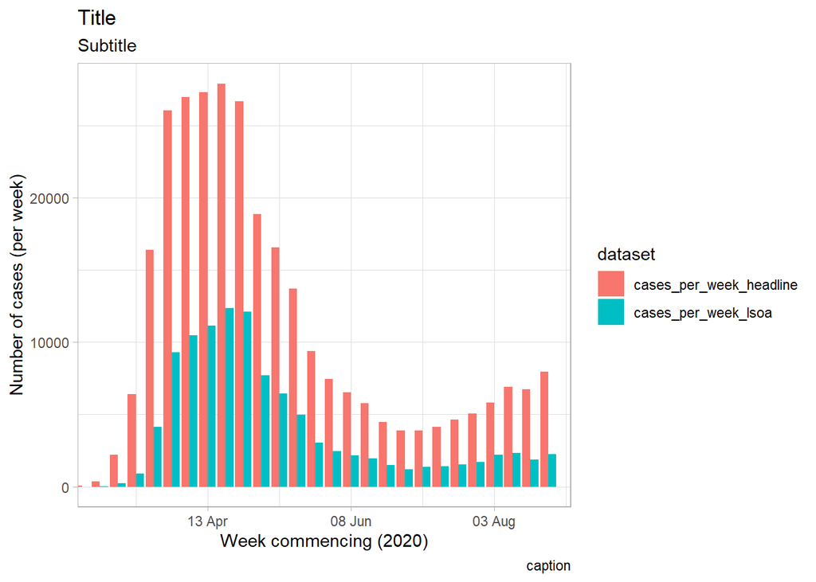

```r
format_cpw_plot <-  function(title = "Title", subtitle = "Subtitle", caption = "caption",
                             sd = start_date, ed = end_date){
  list(
    scale_x_date(date_breaks = "8 weeks", date_labels = "%d %b"),
    coord_x_date(xlim = c(sd, ed)),
    labs(x = "Week commencing (2020)",
         y = "Number of cases (per week)",
         title = title,
         subtitle = subtitle,
         caption = caption),
    theme_light()
  )
}

plot_1 <- ggplot(data = cpw, mapping = aes(x = week_commencing, y = cases_per_week, fill = dataset)) +
            geom_col(position = "dodge") +
            format_cpw_plot()
            #scale_fill_manual(values=c("indianred3" ,"grey")) +

plot(plot_1)
```

Given the scale of the differences between the case numbers in the two datasets, I’ll investigate a little further. Below I plot the ratio between the number of cases in the two datasets. It shows that the headline dataset records between approximately 2 and 4 times as many cases as the LSOA dataset for the period after 16th March. The ratio is not plotted for earlier dates (i.e. early in the pandemic and pre-lockdown) as it is much larger, due to the relatively small number of cases reported in the LSOA dataset. So, I cropped the y axis of the graph to make it easier to view the variation in the ratio in the period since the initial period of ‘lockdown’ implemented by the Government in March 2020.

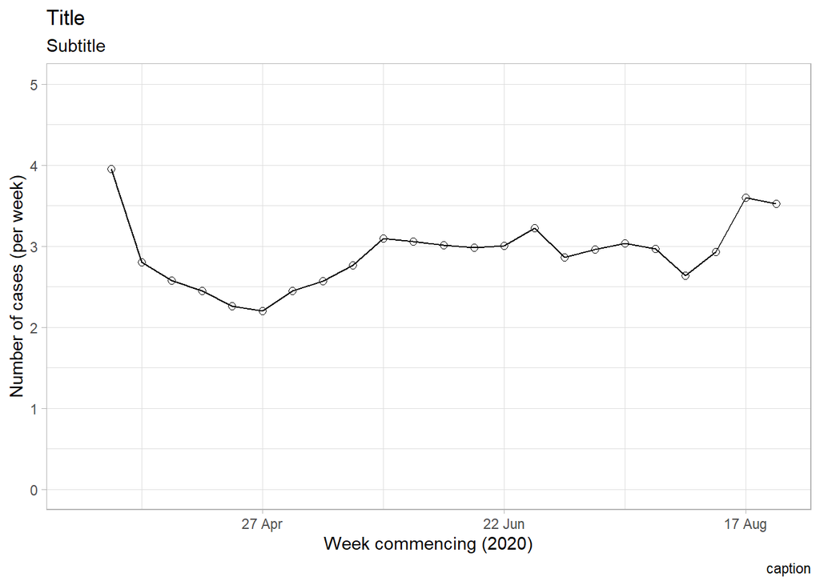

```r
cpw <- cpw %>%
  pivot_wider(names_from = dataset, values_from = cases_per_week) %>%
  mutate(
    `headline:LSOA` = cases_per_week_headline / cases_per_week_lsoa
  ) %>%
  mutate(`headline:LSOA` = replace(`headline:LSOA`, `headline:LSOA` == Inf, NA)) %>%
  pivot_longer(cols = c(cases_per_week_lsoa, cases_per_week_headline),
               names_to = "dataset", values_to = "cases_per_week")

plot_2 <- ggplot(data = cpw, mapping = aes(x = week_commencing, y = `headline:LSOA`)) +
  geom_line() +
  geom_point(shape = 1, size = 2) +
  scale_y_continuous(limits = c(0, 5)) +
  format_cpw_plot(sd = "2020-03-16")
  # scale_x_date(date_breaks = "8 weeks", date_labels = "%d %b") +
  #
  # labs(x = NULL, title = "Title") +
  # coord_x_date(xlim = c("2020-03-02", "2020-08-24")) +
  # theme_light()

plot(plot_2)
```

```r
head(cpw)
```

| week_commencing | headline:LSOA | dataset | cases_per_week |
| --- | --- | --- | --- |
| 2020-01-27 | NA | cases_per_week_lsoa | 0 |
| 2020-01-27 | NA | cases_per_week_headline | 2 |
| 2020-02-03 | NA | cases_per_week_lsoa | 0 |
| 2020-02-03 | NA | cases_per_week_headline | 6 |
| 2020-02-10 | NA | cases_per_week_lsoa | 0 |
| 2020-02-10 | NA | cases_per_week_headline | 1 |

I thought it was worth checking the differences in the number cases in the headline and LSOA datasets were not created by the processing above in this notebook. So, I quickly crosschecked the total number of cases recorded in the two datasets, which again showed large differences.

```r
# lsoa
crosscheck_lsoa <- imported_lsoa
crosscheck_lsoa$lsoa_case_tot <- crosscheck_lsoa %>%
  select(wk_05:wk_35) %>%
  rowSums(na.rm = TRUE)

total_cases_lsoa <- sum(crosscheck_lsoa$lsoa_case_tot)

#headline data
crosscheck_headline <- imported_headline %>%
  filter(areaName == "England") %>%
  filter(date == as_date("2020-08-30"))

total_cases_headline <- crosscheck_headline$cumCasesBySpecimenDate
```

**Total cases (lsoa dataset)**:106752

**Total cases (headline dataset)**: 292025

There are major differences in the ways in which cases are recorded in the headline and lsoa datasets. With only 36.6% of cases recorded in the headline dataset appearing in the LSOA dataset. So, I emailed the data owners to ask for more information on the differences in case numbers between the LSOA and headline datasets and received the following reply.

09/09/2020 from coronavirus-tracker@phe.gov.uk

"Hi Chris,

We have to suppress the number of cases if they are below 3, hence the LSOA file will not show if there were 1 or 2 cases in an area and they will be missed in the totals.

Regards"

### 4.2. Exploring options for -99 entries in LSOA data

```r
probabilities <- list(
  #         c(p(0), p(1), p(2))
  probs_1 = c(1, 0, 0),
  probs_2 = c(0, 1, 0),
  probs_3 = c(0, 0, 1),
  probs_4 = c( 1 / 3, 1 / 3, 1 / 3)
)
```

```r
processed_lsoa_alt <- processed_lsoa

# for each set of probabilities create a new column cases in the df and label accordingly
for (i in seq_along((probabilities))){
  # create columns for cases by processing option
  col_name <- str_c("cases_alt_p_", i)

  # replace na with c(0, 1, 2) according to probabilities defined above
  column <- processed_lsoa_alt[["cases"]]
  column[is.na(column)] <-
    sample(
      c(0,1,2),
      size = sum(is.na(column)),
      prob = probabilities[[i]],
      replace = TRUE
    )

  processed_lsoa_alt[col_name] <- column
}

head(processed_lsoa_alt)
```

| lsoa_id | lsoa_name | week_commencing | cases | cases_alt_p_1 | cases_alt_p_2 | cases_alt_p_3 | cases_alt_p_4 |
| --- | --- | --- | --- | --- | --- | --- | --- |
| E01000001 | City of London 001A | 2020-01-27 | NA | 0 | 1 | 2 | 0 |
| E01000001 | City of London 001A | 2020-02-03 | NA | 0 | 1 | 2 | 0 |
| E01000001 | City of London 001A | 2020-02-10 | NA | 0 | 1 | 2 | 0 |
| E01000001 | City of London 001A | 2020-02-17 | NA | 0 | 1 | 2 | 2 |
| E01000001 | City of London 001A | 2020-02-24 | NA | 0 | 1 | 2 | 2 |
| E01000001 | City of London 001A | 2020-03-02 | NA | 0 | 1 | 2 | 0 |

An unsuccessful attempt at a functional approach to the fill in the nas in the lsoa dataset.

```r
lsoa_na_replace <- function(cases, p){

#   print(p)
   # replace na with c(0, 1, 2) according to probabilities in p
   cases[is.na(cases)] <-
     sample(
       c(0,1,2),
       size = sum(is.na(cases)),
       prob = p,
       replace = TRUE
     )

   return(cases)
 }


 lsoa_na_options <- function(p, df){

   # create columns for cases by processing option
   col_name <- str_c("cases_", names(p))
   res <- lsoa_na_replace(df[["cases"]], p)
   #names(res) <- col_name
   res
}

processed_lsoa_alt <- processed_lsoa

proc_opt_cols <- map(probabilities, lsoa_na_options, df = processed_lsoa_alt) %>%
  set_names(c("a", "b", "c", "d"))
#proc_opt_df <- map_dfr(proc_opt_cols, as.list)

processed_lsoa_alt %>%
   add_column(processed_lsoa_alt, proc_opt_cols[1])

#
#
# # processed_lsoa_alt <- lsoa_na_options(processed_lsoa_alt, probabilities)
# # str(processed_lsoa_alt)
```

```r
# tidy data
processed_lsoa_alt <- processed_lsoa_alt %>%
  pivot_longer(cols = cases:ncol(processed_lsoa_alt),
               values_to = "cases",
               names_to = "processing")

head(processed_lsoa_alt)
```

| lsoa_id | lsoa_name | week_commencing | processing | cases |
| --- | --- | --- | --- | --- |
| E01000001 | City of London 001A | 2020-01-27 | cases | NA |
| E01000001 | City of London 001A | 2020-01-27 | cases_alt_p_1 | 0 |
| E01000001 | City of London 001A | 2020-01-27 | cases_alt_p_2 | 1 |
| E01000001 | City of London 001A | 2020-01-27 | cases_alt_p_3 | 2 |
| E01000001 | City of London 001A | 2020-01-27 | cases_alt_p_4 | 0 |
| E01000001 | City of London 001A | 2020-02-03 | cases | NA |

```r
cpw_lsoa_alt <- processed_lsoa_alt %>%
  # calculate case numbers per week (for each processing approach)
  get_cases_per_week(case_col = cases, na.rm = TRUE, processing) #%>%
head(cpw_lsoa_alt)
```

| week_commencing | processing | cases_per_week |
| --- | --- | --- |
| 2020-01-27 | cases | 0 |
| 2020-01-27 | cases_alt_p_1 | 0 |
| 2020-01-27 | cases_alt_p_2 | 32845 |
| 2020-01-27 | cases_alt_p_3 | 65690 |
| 2020-01-27 | cases_alt_p_4 | 32851 |
| 2020-02-03 | cases | 0 |

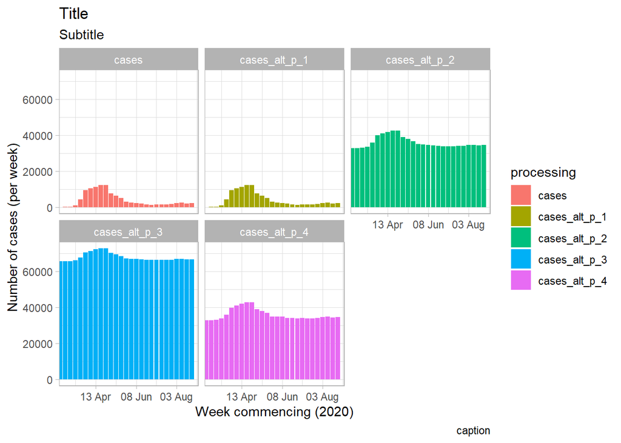

```r
# Facet plot the alternative approaches to processing NA (coded as -99 in source data)values
ggplot(data = cpw_lsoa_alt, mapping = aes(
        x = week_commencing, y = cases_per_week, fill = processing)) +
  geom_col() +
  format_cpw_plot() +
  facet_wrap(~ processing)
```

```r
# cases_lsoa_p2 <- tidy_lsoa
# #   mutate(cases = replace_na(cases, sample(0:2, 1, replace = TRUE, prob = c(0.6, 0.25, 0.15))))
#
# cases_lsoa_p2$cases[is.na(cases_lsoa_p2$cases)] <- sample(
#   c(0,1,2),
#   size=sum(is.na(cases_lsoa_p2$cases)),
#   prob = c(0.5, 0.25, 0.25),
#   replace=TRUE
#   )
#
# #sample(c(0, 1, 2), 1, replace = TRUE)
#
# sum(cases_lsoa_p2$cases)
```

https://cran.r-project.org/web/packages/RSQLite/vignettes/RSQLite.html

```r
covid_19_db <- dbConnect(RSQLite::SQLite(), "covid-19_db.sqlite")
dbWriteTable(covid_19_db, "cpw", cpw, overwrite = TRUE)

dbGetQuery(covid_19_db, "SELECT * FROM cpw")
```

| week_commencing | headline:LSOA | dataset | cases_per_week |
| --- | --- | --- | --- |
| 18288 | NA | cases_per_week_lsoa | 0 |
| 18288 | NA | cases_per_week_headline | 2 |
| 18295 | NA | cases_per_week_lsoa | 0 |
| 18295 | NA | cases_per_week_headline | 6 |
| 18302 | NA | cases_per_week_lsoa | 0 |
| 18302 | NA | cases_per_week_headline | 1 |
| 18309 | NA | cases_per_week_lsoa | 0 |
| 18309 | NA | cases_per_week_headline | 2 |
| 18316 | NA | cases_per_week_lsoa | 0 |
| 18316 | NA | cases_per_week_headline | 54 |

[output cut: 52 more lines]

```r
dbDisconnect(covid_19_db)
#unlink("my-db.sqlite")
```

## Ideas

- against national trends
  - proportions of cases
- Against hotspots / places with local lockdowns https://www.instituteforgovernment.org.uk/explainers/coronavirus-local-lockdowns
- correlation
  - cases and household type https://www.nomisweb.co.uk/census/2011/ks403ew
  - cases and self report tool symptoms https://covid.joinzoe.com/data
  - cases and deprivation https://github.com/britishredcrosssociety/covid-19-vulnerability
- NHS Digital open data sets https://digital.nhs.uk/dashboards